# Practical Machine Learning Course Project

Samarkande

January 19, 2016

# Introduction

**Background**

Using devices such as *Jawbone Up, Nike FuelBand, and Fitbit* is now possible to collect a large amount of data about personal activity relatively inexpensively. These type of devices are part of the quantified self movement – a group of enthusiasts who take measurements about themselves regularly to improve their health, to find patterns in their behavior, or because they are tech geeks. One thing that people regularly do is quantify how *much* of a particular activity they do, but they rarely quantify *how well they do it*.  
In this project, we will be to use data from accelerometers on the belt, forearm, arm, and dumbell of six participants. They were asked to perform barbell lifts correctly and incorrectly in 5 different classes as follows:

- `Class A`: Exactly according to the specification
- `Class B`; Throwing the elbows to the front
- `Class C`: Lifting the dumbbell only halfway
- `Class D`: Lowering the dumbbell only halfway
- `Class E`: Throwing the hips to the front

More information is available from the website [here](http://groupware.les.inf.puc-rio.br/har) (see the section on the Weight Lifting Exercise Dataset).

**Data**

For this project, the training and test data sets are [here](https://d396qusza40orc.cloudfront.net/predmachlearn/pml-training.csv) and [here](https://d396qusza40orc.cloudfront.net/predmachlearn/pml-testing.csv), respectively.

**Goal**

The goal of your project is to predict the manner in which they did the exercise. This is the “`classe`” variable in the training set. You may use any of the other variables to predict with. You should create a report describing how you built your model, how you used cross validation, what you think the expected out of sample error is, and why you made the choices you did. You will also use your prediction model to predict 20 different test cases.

Your submission for the Peer Review portion should consist of a link to a Github repo with your R markdown and compiled HTML file describing your analysis. Please constrain the text of the writeup to < 2000 words and the number of figures to be less than 5. It will make it easier for the graders if you submit a repo with a gh-pages branch so the HTML page can be viewed online (and you always want to make it easy on graders).

# Results

**Data Processing**

```r
# Required libraries
suppressMessages(library(caret))
suppressMessages(library(dplyr))
```

```r
suppressMessages(library(ggplot2))
suppressMessages(library(rpart.plot))
suppressMessages(library(e1071))  # Skewness function use
# Setting seed for reproducibility
set.seed(123)
```

```r
# Create Data repo
if(!dir.exists('./Data')){dir.create('./Data')}

# Create Figures repo
if(!dir.exists('./Figures')){dir.create('./Figures')}

# Load train data set
if(!file.exists('./Data/pml-training.csv')){
fileUrl<- 'https://d396qusza40orc.cloudfront.net/predmachlearn/pml-training.csv'
download.file(fileUrl,destfile='./Data/pml-training.csv',mode = 'wb')
}

# Load test data set
if(!file.exists('./Data/pml-testing.csv')){
fileUrl<- 'https://d396qusza40orc.cloudfront.net/predmachlearn/pml-testing.csv'
download.file(fileUrl,destfile='./Data/pml-testing.csv',mode = 'wb')
}

# Load train data set
mydata_train <- read.csv("Data/pml-training.csv", na.strings=c("NA", ""))

# Load test data set
mydata_test <- read.csv("Data/pml-testing.csv", na.strings=c("NA", ""))

# Check dimension of data sets
dim(mydata_train); dim(mydata_test)
```

```
## [1] 19622   160
```

```
## [1]  20 160
```

The training and test data sets have $19622$ and $20$ observations, respectively. Both have $160$ variables (or predictors).

```r
# Check structure of train data set
str(mydata_train)
```

```
## 'data.frame':    19622 obs. of  160 variables:
##  $ X                       : int  1 2 3 4 5 6 7 8 9 10 ...
##  $ user_name               : Factor w/ 6 levels "adelmo","carlitos",..: 2 2 2 2 2 2 2 2 2 2 ...
##  $ raw_timestamp_part_1    : int  1323084231 1323084231 1323084231 1323084232 1323084232 1323084232 1323084232 1323084232 1323084232 1323084232 ...
##  $ raw_timestamp_part_2    : int  788290 808298 820366 120339 196328 304277 368296 440390 484323 484434 ...
##  $ cvtd_timestamp          : Factor w/ 20 levels "02/12/2011 13:32",..: 9 9 9 9 9 9 9 9 9 9 ...
##  $ new_window              : Factor w/ 2 levels "no","yes": 1 1 1 1 1 1 1 1 1 1 ...
##  $ num_window              : int  11 11 11 12 12 12 12 12 12 12 ...
##  $ roll_belt               : num  1.41 1.41 1.42 1.48 1.48 1.45 1.42 1.42 1.43 1.45 ...
##  $ pitch_belt              : num  8.07 8.07 8.07 8.05 8.07 8.06 8.09 8.13 8.16 8.17 ...
##  $ yaw_belt                : num  -94.4 -94.4 -94.4 -94.4 -94.4 -94.4 -94.4 -94.4 -94.4 -94.4 ...
##  $ total_accel_belt        : int  3 3 3 3 3 3 3 3 3 3 ...
##  $ kurtosis_roll_belt      : Factor w/ 396 levels "-0.016850","-0.021024",..: NA NA NA NA NA NA NA NA NA NA ...
##  $ kurtosis_picth_belt     : Factor w/ 316 levels "-0.021887","-0.060755",..: NA NA NA NA NA NA NA NA NA NA ...
##  $ kurtosis_yaw_belt       : Factor w/ 1 level "#DIV/0!": NA NA NA NA NA NA NA NA NA NA ...
```

[output cut: 86 more lines]

We can see from the above that some variables have important numbers of NA values. Let’s check in details this presence of NAs:

```r
# Number of variables with stricly NA values
sum(colSums(is.na(mydata_train))==dim(mydata_train)[1])
```

```
## [1] 0
```

```r
# Number of variables with over 95 % of NA values
sum(colSums(is.na(mydata_train))>=0.95*dim(mydata_train)[1])
```

```
## [1] 100
```

```r
# Number of variables without NA values
sum(colSums(!is.na(mydata_train))==dim(mydata_train)[1])
```

```
## [1] 60
```

There is zero predictor with stricly NAs. However, $100$ variables are composed of at least $95$% of NAs, while $60$ variables have no NAs. In these conditions, we consider these last predictors (with no NAs). Moreover, we also omit the first seven variables (related to the ID of persons) which have a minor influence on the outcome `classe`:

```r
# Find variables (without NAs)
NoNA_Var<- which(colSums(!is.na(mydata_train))==dim(mydata_train)[1])
# Take into account the above variables without the first seven variables
mydata_train <- mydata_train %>% select(NoNA_Var) %>% select(-c(1:7))
mydata_test <- mydata_test %>% select(NoNA_Var) %>% select(-c(1:7))
```

Let’s check variables with very low variance:

```r
# Find our variables (without NAs)
nearZeroVar(mydata_train)
```

```
## integer(0)
```

No variables with very low variance are found in our train data set. Let’s also omit highly correlated variables (over correlation of 0.9) as follows:

```r
# Correlation values between variables
correlations<-  cor(select(mydata_train,-classe))
# Cut off correlation over 0.9
highCorr<-  findCorrelation(correlations, cutoff=  0.9)
# Subset data with our correlation limit
mydata_train<- mydata_train %>% select(-highCorr)
mydata_test<- mydata_test %>% select(-highCorr)
```

Most of predictive models are based on predicators’ normal distributions. Then, let’s now scale our data sets:

```r
# Preprocessing: scaling, skewness (without the outcome 'classe')
trans<-  preProcess(select(mydata_train,-classe),method=  c('center','scale','BoxCox'))

# Transformed data (train and test) sets
mydata_train_trans<- predict(trans,select(mydata_train,-classe))
mydata_test_trans<- predict(trans,select(mydata_test,-classe))
```

We also neglect the remaining highly skew variables as follows:

```r
# Variables with highly skewness
Skew_var<- apply(mydata_train_trans,2,skewness) > 10
# Omit skew variables on data sets
mydata_train_trans<- mydata_train_trans[!Skew_var]
mydata_test_trans<- mydata_test_trans[!Skew_var]

# Add the 'classe' column
mydata_train_trans<- mydata_train_trans %>% mutate(classe=mydata_train$classe)
mydata_test_trans<- mydata_test_trans %>% mutate(classe=mydata_test$classe)

# Check our transformed data sets
dim(mydata_train_trans)
```

```
## [1] 19622    43
```

```r
dim(mydata_test_trans)
```

```
## [1] 20 43
```

We reduced our initial data sets to have $43$ variables.

**Data Split**  
The train data set is splitted into a subtrain (to build the predictive model) and a validation (to check the accuracy) parts. The test data set is used in last to predict the required outcomes for this project.

```r
# Indexes of splitting (subtrain 80% and validation 20% of the train data set)
Ind_part <- createDataPartition(y=mydata_train_trans$classe, p=0.8, list=F)
# Split into sub_training and validation parts
mydata_sub_train<- mydata_train_trans[Ind_part,]
mydata_valid<- mydata_train_trans[-Ind_part,]

# Dimension of data sets
dim(mydata_sub_train)
```

```
## [1] 15699    43
```

```r
dim(mydata_valid)
```

```
## [1] 3923   43
```

The subtrain and validation data sets are splitted from $80$% and $20$% of the train data set, respectively.

**Predictive Models**  
The present project is a classification study in *if-then* kinds of ways. Obviously, we first use the Decision Tree model, and if necesssary the Random Forest algorithm (both from the caret package).

The k-fold cross validation resampling technique is used in this study:

```r
# Type of resampling / 5-fold cross-validation
control  <-  trainControl(method= 'cv', number=  5)
```

*Decision Tree*

```r
# Build the predictive model on the subtrain data set
DT_model<- train(classe~. , data=mydata_sub_train, method= 'rpart')
# Predict on the validation data set
prediction<- predict(DT_model, mydata_valid)
# Confusion matrix on the validation data set
confusionMatrix(prediction, mydata_valid$classe)
```

```
## Confusion Matrix and Statistics
##
##           Reference
## Prediction    A    B    C    D    E
##          A 1015  308  304  258  149
##          B   16  262   26  132  132
##          C   68  155  280   62  168
##          D   17   34   74  155   23
##          E    0    0    0   36  249
##
## Overall Statistics
##
##                Accuracy : 0.4999
##                  95% CI : (0.4841, 0.5156)
##     No Information Rate : 0.2845
##     P-Value [Acc > NIR] : < 2.2e-16
##
##                   Kappa : 0.347
##  Mcnemar's Test P-Value : < 2.2e-16
##
## Statistics by Class:
##
##                      Class: A Class: B Class: C Class: D Class: E
## Sensitivity            0.9095  0.34519  0.40936  0.24106  0.34535
## Specificity            0.6370  0.90329  0.86014  0.95488  0.98876
## Pos Pred Value         0.4990  0.46127  0.38199  0.51155  0.87368
## Neg Pred Value         0.9465  0.85186  0.87335  0.86519  0.87026
## Prevalence             0.2845  0.19347  0.17436  0.16391  0.18379
## Detection Rate         0.2587  0.06679  0.07137  0.03951  0.06347
## Detection Prevalence   0.5185  0.14479  0.18685  0.07724  0.07265
## Balanced Accuracy      0.7732  0.62424  0.63475  0.59797  0.66706
```

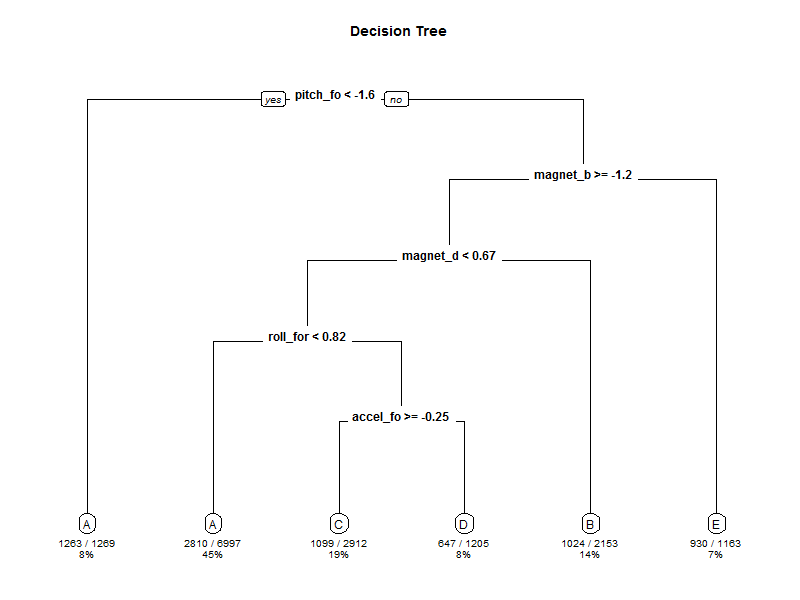

```r
# Plot the Decision Tree
png('./Figures/unnamed-chunk-13.png',width=800,height=600)

rpart.plot(DT_model$finalModel, main="Decision Tree", extra=102, under=T, faclen=0, cex = 1,branch = 1, type = 0, fallen.leaves = T)

dev.off()
```

The low accuracy value (~$50$%) shows that the Decision Tree is a bad classifier for the present study. Let’s check with the Random Forest model:

*Random Forest*

```r
# Build the predictive model on the subtrain data set
RF_model<- train(classe~., data=mydata_sub_train, method = "rf", trControl = control)
# Predict on the validation data set
prediction <- predict(RF_model, mydata_valid)
# Confusion matrix on the validation data set
confusionMatrix(prediction, mydata_valid$classe)
```

```
## Confusion Matrix and Statistics
##
##           Reference
## Prediction    A    B    C    D    E
##          A 1115    8    0    0    0
##          B    1  746    3    0    0
##          C    0    5  680    4    0
##          D    0    0    1  638    1
##          E    0    0    0    1  720
##
## Overall Statistics
##
##                Accuracy : 0.9939
##                  95% CI : (0.9909, 0.9961)
##     No Information Rate : 0.2845
##     P-Value [Acc > NIR] : < 2.2e-16
##
##                   Kappa : 0.9923
##  Mcnemar's Test P-Value : NA
##
## Statistics by Class:
##
##                      Class: A Class: B Class: C Class: D Class: E
## Sensitivity            0.9991   0.9829   0.9942   0.9922   0.9986
## Specificity            0.9971   0.9987   0.9972   0.9994   0.9997
## Pos Pred Value         0.9929   0.9947   0.9869   0.9969   0.9986
## Neg Pred Value         0.9996   0.9959   0.9988   0.9985   0.9997
## Prevalence             0.2845   0.1935   0.1744   0.1639   0.1838
## Detection Rate         0.2842   0.1902   0.1733   0.1626   0.1835
## Detection Prevalence   0.2863   0.1912   0.1756   0.1631   0.1838
## Balanced Accuracy      0.9981   0.9908   0.9957   0.9958   0.9992
```

As expected, the Random Forest is a better predictive model than the Decision Tree. Indeed, the Random Forest has a larger accuracy (99.4%). Let’s now consider the first $30$ most important predictors of the Random Forest model (to reduce computing cost):

```r
# Names of first important variables
Imp_vars<-rownames(varImp(RF_model)$importance)[1:30]
# Build the predictive model on the subtrain data set (with the most important predictors)
RF_model_2<- train(classe~., data=mydata_sub_train[c(Imp_vars,'classe')], method = "rf", trControl = control)
# Predict on the validation data set
prediction <- predict(RF_model_2, mydata_valid[c(Imp_vars,'classe')])
# Confusion matrix on the validation data set
confusionMatrix(prediction, mydata_valid$classe)
```

```
## Confusion Matrix and Statistics
##
##           Reference
## Prediction    A    B    C    D    E
##          A 1112   11    1    2    0
##          B    2  740    4    0    0
##          C    1    7  676   11    1
##          D    1    0    3  629    3
##          E    0    1    0    1  717
##
## Overall Statistics
##
##                Accuracy : 0.9875
##                  95% CI : (0.9835, 0.9907)
##     No Information Rate : 0.2845
##     P-Value [Acc > NIR] : < 2.2e-16
##
##                   Kappa : 0.9842
##  Mcnemar's Test P-Value : NA
##
## Statistics by Class:
##
##                      Class: A Class: B Class: C Class: D Class: E
## Sensitivity            0.9964   0.9750   0.9883   0.9782   0.9945
## Specificity            0.9950   0.9981   0.9938   0.9979   0.9994
## Pos Pred Value         0.9876   0.9920   0.9713   0.9890   0.9972
## Neg Pred Value         0.9986   0.9940   0.9975   0.9957   0.9988
## Prevalence             0.2845   0.1935   0.1744   0.1639   0.1838
## Detection Rate         0.2835   0.1886   0.1723   0.1603   0.1828
## Detection Prevalence   0.2870   0.1902   0.1774   0.1621   0.1833
## Balanced Accuracy      0.9957   0.9865   0.9911   0.9880   0.9969
```

In the above condition, we have an acccuracy of $0.9875$ (in 95% CI: [0.9835, 0.9907]).**The out of sample error is $1.25$% (=1-accuracy) which leads to consider the Random Forest model as a good classifier** to predict outcomes of the test data set as follows:

```r
# predict on the validation data set
result_1<-predict(RF_model, mydata_test_trans)
# predict on the validation data set (with the first 30 important predictors)
result_2<-predict(RF_model_2, mydata_test_trans[c(Imp_vars,'classe')])
```

Note that we have similar predictive results with the first important and all predictors:

```r
identical(result_1,result_2)
```

```
## [1] TRUE
```

With this condition, the required $20$ outcomes for this project are the following:

```r
result_2
```

```
##  [1] B A B A A E D B A A B C B A E E A B B B
## Levels: A B C D E
```

# Conclusions

A study is presented to predict barbell lifts according to different classes. Data sets (train and test) are first reduced via the characteristics of predictors. These characteristics are the percentage of NAs values, low variance, correlation and skewness. The variables of the data sets are also scaled. The train data set is splitted into subtrain and validation parts to construct a predictive model and evaluate its accuracy. Decision Tree and Random Forest are applied (from the caret package) and it was found that this latter is more accurate and gives satisfactory results even with the most important predictors in the aim to reduce computing cost (with an out of sample error of $1.25$%).